# User_analysis

袁青野

# 本报告对2017-12-29用户至2018-01-11这两周的行为进行了分析

#### 包括反映用户数目的UV,反映用户活跃度的：人均PV,用户活跃时长,以及反映用户黏度的次日留存，本次报告加入了路径深度的分析,加入了转化部分,并采用多种方式作图

#### 本次报告用R语言自动化生成报告的框架搭建，今后将在此基础上不断改进优化

## 近两周的日活跃度(UV)

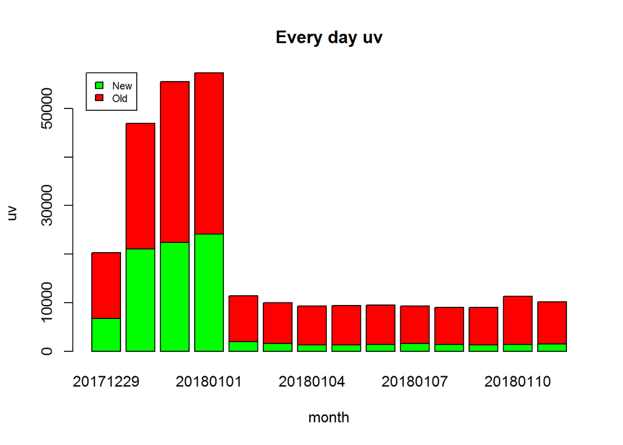

平均UV为19906,

最大UV为57334,

最大值发生在20180101

有0 天新用户在UV值上超过老用户

20171230 用户UV明显高于平均值 20180102 用户UV明显低于平均值

12月30日到1月1日这三天日用户（UV）很高

## 近两周人均PV

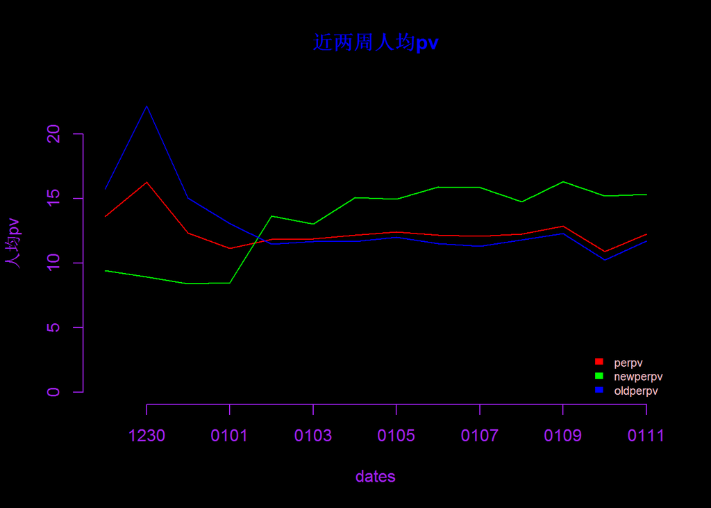

总体PV均值为12.4382364

总体PV最大值为16.2509796 最大值发生在 20171230

总体PV最小值为10.8824047 最小值发生在 20180110

新用户PV均值为13.2294454

新用户PV最大值为16.3203065 最大值发生在 20180109

新用户PV最小值为8.3934938 最小值发生在 20171231

老用户PV均值为12.980041

老用户PV最大值为22.1758466 最大值发生在 20171230

老用户PV最小值为10.2613075 最小值发生在 20180110

有10 天新用户在人均PV值上超过老用户

20171230, 20180101, 20180102, 20180103, 20180104, 20180105, 20180106, 20180108 新用户和老用户的趋势不一样

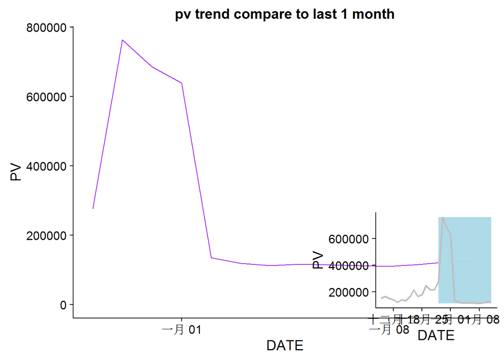

画中画分析，大图，小图中高亮处均表示示近两周pv趋势，而小图整体表示近一个月的pv情况 近两周波动比较明显

12月30日,12月31日到1月1日属于峰值

之后就一直较低

## 用户活跃时长

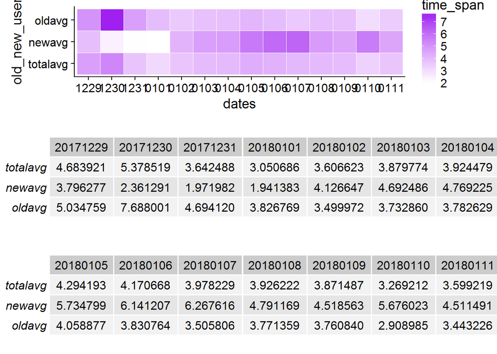

对于用户访问时长作的热力图

以1月1日为分界线，新年前老用户访问时长高于新用户访问时长，但在新年后出现了新用户访问时长高于老用户访问时长的现象

在12月30日，12月31日至1月1日，新用户访问时长很低

老用户在12月30日访问时间达到峰值，其他时间没有达到这样的高度

## 次日留存

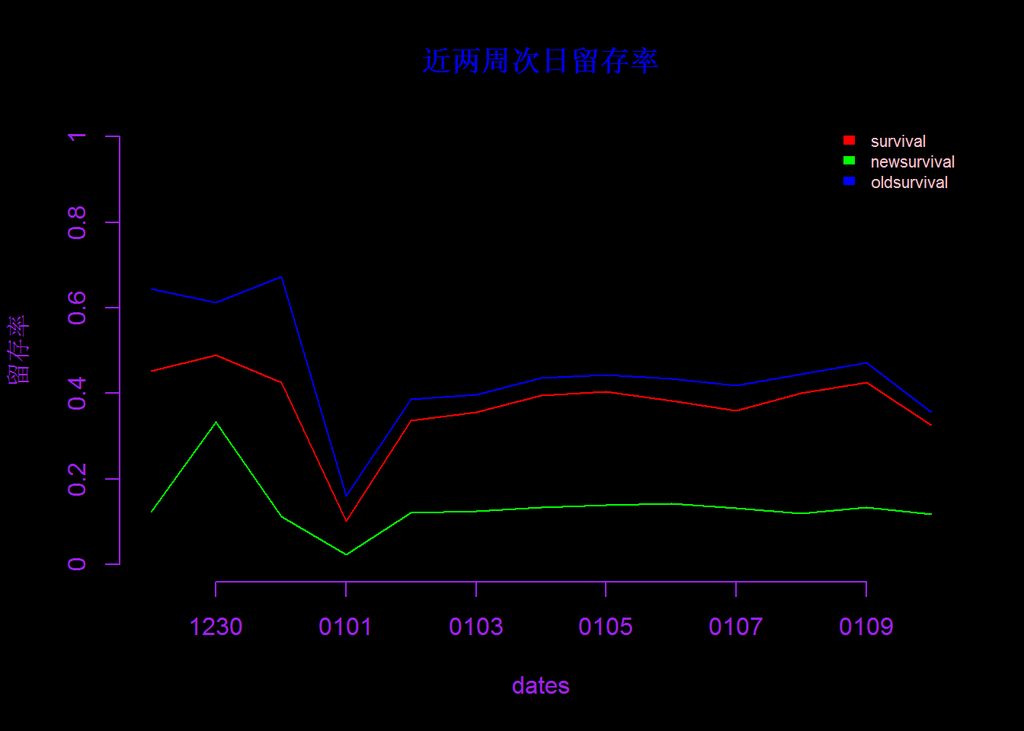

## 新老用户访问平均深度（按用户）

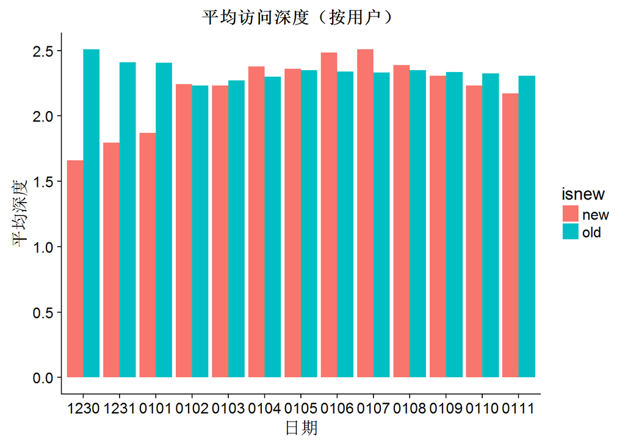

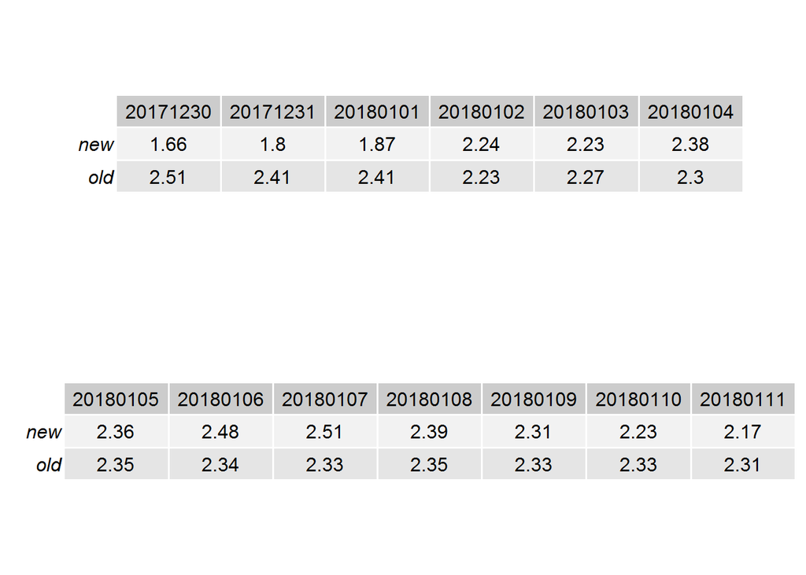

老用户访问深度几乎总大于2，新用户访问深度在2的上下波动

[figure not shown]

总体来看，新老用户访问深度差异不像之前几个月那么明显了

## 新用户不同机型分布

|  | sym | model | 2017-12-29 | 2017-12-30 | 2017-12-31 | 2018-01-01 | 2018-01-02 | 2018-01-03 | 2018-01-04 | 2018-01-05 | 2018-01-06 | 2018-01-07 | 2018-01-08 | 2018-01-09 | 2018-01-10 | 2018-01-11 | sum | rank |
| --- | --- | --- | --- | --- | --- | --- | --- | --- | --- | --- | --- | --- | --- | --- | --- | --- | --- | --- |
| 1 | 1▲ | iPhone 6s | 858 | 2168 | 2675 | 2205 | 91 | 72 | 64 | 65 | 83 | 65 | 62 | 64 | 46 | 89 | 8607 | 1 |
| 2 | -1▼ | iPhone 6 | 839 | 3424 | 1813 | 1321 | 96 | 67 | 65 | 46 | 56 | 89 | 63 | 77 | 89 | 67 | 8112 | 2 |
| 3 | 1▲ | iPhone 5s | 568 | 1385 | 1161 | 1001 | 12 | 11 | 10 | 25 | 5 | 3 | 7 | 12 | 23 | 21 | 4244 | 3 |
| 4 | -1▼ | iPhone 6 Plus | 515 | 1089 | 1000 | 877 | 67 | 32 | 52 | 47 | 44 | 33 | 69 | 35 | 45 | 51 | 3956 | 4 |
| 5 | 3▲ | iPhone 5c | 661 | 1108 | 842 | 818 | 4 |  | 2 | 1 |  | 1 |  |  | 13 | 8 | 3458 | 5 |
| 6 | 3▲ | iPhone 5 | 359 | 1186 | 972 | 906 | 3 | 3 |  | 2 | 3 |  |  | 2 | 9 | 5 | 3450 | 6 |
| 7 | -1▼ | iPhone 6s Plus | 454 | 882 | 756 | 704 | 76 | 61 | 57 | 41 | 70 | 51 | 66 | 66 | 54 | 70 | 3408 | 7 |
| 8 | -3▼ | iPhone 7 Plus | 424 | 596 | 495 | 559 | 109 | 86 | 51 | 71 | 96 | 113 | 98 | 96 | 94 | 116 | 3004 | 8 |
| 9 | -2▼ | iPhone 7 | 381 | 528 | 436 | 525 | 77 | 69 | 65 | 71 | 64 | 50 | 74 | 71 | 83 | 82 | 2576 | 9 |
| 10 | 22▲ | iPhone 4S | 81 | 503 | 451 | 347 |  |  |  |  | 2 |  | 1 | 1 | 2 | 9 | 1397 | 10 |

[output cut: 90 more lines]

iphone手机排名前列，前十名全部被iphone系列手机占据,之后是Vivo系列还有 红米等手机，安卓机偏少

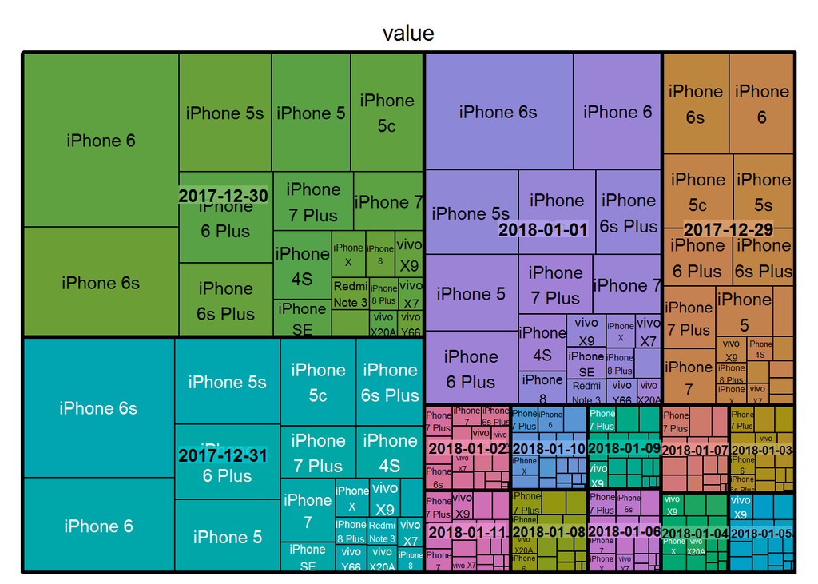

结构矩形树图，大矩形为日期，小矩形为具体机型，按从大到小的顺序，从上到下，从左到右排列

## 新用户不同城市分布

|  | sym | city | 2017-12-29 | 2017-12-30 | 2017-12-31 | 2018-01-01 | 2018-01-02 | 2018-01-03 | 2018-01-04 | 2018-01-05 | 2018-01-06 | 2018-01-07 | 2018-01-08 | 2018-01-09 | 2018-01-10 | 2018-01-11 | sum | rank |
| --- | --- | --- | --- | --- | --- | --- | --- | --- | --- | --- | --- | --- | --- | --- | --- | --- | --- | --- |
| 1 | 1▲ | 上海 | 446 | 2288 | 1791 | 1544 | 242 | 160 | 179 | 123 | 178 | 198 | 165 | 148 | 243 | 152 | 7614 | 1 |
| 2 | 1▲ | 苏州 | 470 | 2152 | 2703 | 1416 | 71 | 87 | 59 | 83 | 60 | 83 | 63 | 61 | 58 | 56 | 7364 | 2 |
| 3 | 51▲ | 泉州 | 18 | 1156 | 2038 | 3552 | 10 | 3 | 3 | 8 | 15 | 9 | 4 | 11 | 12 | 6 | 6833 | 3 |
| 4 | 0 | 南京 | 305 | 1515 | 1332 | 1115 | 110 | 96 | 70 | 165 | 110 | 155 | 87 | 94 | 55 | 61 | 5215 | 4 |
| 5 | -4▼ | 北京 | 423 | 1169 | 845 | 538 | 201 | 190 | 171 | 156 | 186 | 190 | 204 | 147 | 162 | 148 | 4568 | 5 |
| 6 | 212▲ | 漯河 | 5 | 689 | 1305 | 1620 | 1 | 5 |  | 2 | 2 | 5 | 9 | 1 |  | 1 | 3645 | 6 |
| 7 | -2▼ | 石家庄 | 304 | 258 | 334 | 2006 | 57 | 68 | 51 | 106 | 97 | 55 | 55 | 44 | 74 | 131 | 3566 | 7 |
| 8 | -2▼ | 重庆 | 421 | 494 | 257 | 163 | 88 | 116 | 112 | 75 | 91 | 93 | 86 | 75 | 80 | 60 | 2131 | 8 |
| 9 | 6▲ | 合肥 | 150 | 573 | 183 | 794 | 33 | 41 | 44 | 25 | 32 | 44 | 48 | 21 | 27 | 33 | 2021 | 9 |
| 10 | 2▲ | 无锡 | 64 | 361 | 379 | 617 | 58 | 30 | 27 | 36 | 47 | 37 | 37 | 44 | 34 | 39 | 1776 | 10 |

[output cut: 91 more lines]

整体流量平稳偏低 上海，苏州,泉州占据前三名

泉州，漯河，长沙，台州名次上升较多（也有可能是由于前面城市的下降）

其中，漯河，泉州，石家庄数据有一定异常

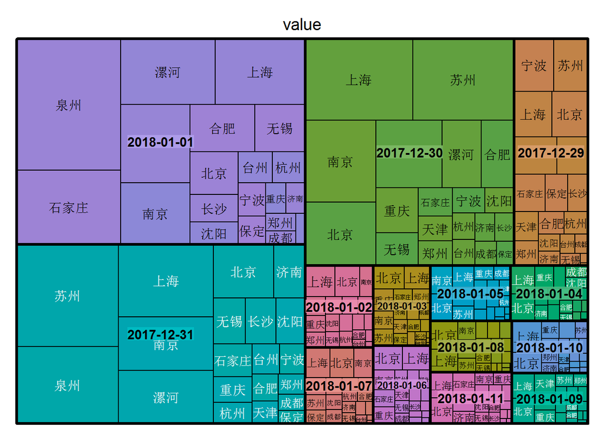

结构矩形树图，大矩形为日期，小矩形为具体城市，按从大到小的顺序，从上到下，从左到右排列

## 新用户不同渠道分布

|  | channels | 2017-12-29 | 2017-12-30 | 2017-12-31 | 2018-01-01 | 2018-01-02 | 2018-01-03 | 2018-01-04 | 2018-01-05 | 2018-01-06 | 2018-01-07 | 2018-01-08 | 2018-01-09 | 2018-01-10 | 2018-01-11 | sum |
| --- | --- | --- | --- | --- | --- | --- | --- | --- | --- | --- | --- | --- | --- | --- | --- | --- |
| 1 | 二维码-Android | 766 | 5566 | 9119 | 10710 | 93 | 18 | 30 | 52 | 28 | 86 | 21 | 36 | 46 | 102 | 26673 |
| 2 | 二维码-IOS | 923 | 8579 | 5634 | 5318 | 41 | 14 | 15 | 48 | 42 | 38 | 17 | 27 | 93 | 123 | 20912 |
| 3 | Appstore | 3468 | 3603 | 4294 | 3544 | 452 | 392 | 333 | 308 | 368 | 385 | 350 | 311 | 277 | 300 | 18385 |
| 4 | 30015 | 149 | 1330 | 1616 | 3008 | 26 | 21 | 24 | 15 | 23 | 28 | 18 | 10 | 57 | 18 | 6343 |
| 5 | vivo | 360 | 369 | 318 | 264 | 346 | 346 | 299 | 293 | 337 | 377 | 328 | 307 | 335 | 302 | 4581 |
| 6 | 小米 | 400 | 521 | 508 | 292 | 394 | 156 | 115 | 97 | 101 | 134 | 113 | 84 | 92 | 69 | 3076 |
| 7 | 华为 | 201 | 350 | 293 | 296 | 158 | 165 | 139 | 136 | 137 | 192 | 166 | 134 | 145 | 151 | 2663 |
| 8 | 二维码-其他 | 138 | 380 | 222 | 291 | 96 | 18 | 31 | 23 | 19 | 15 | 10 | 27 | 26 | 29 | 1325 |
| 9 | 360手助 | 59 | 108 | 88 | 144 | 70 | 86 | 72 | 80 | 75 | 99 | 49 | 79 | 91 | 103 | 1203 |
| 10 | 百度手助 | 87 | 88 | 85 | 86 | 58 | 44 | 39 | 46 | 41 | 39 | 40 | 85 | 75 | 83 | 896 |

[output cut: 23 more lines]

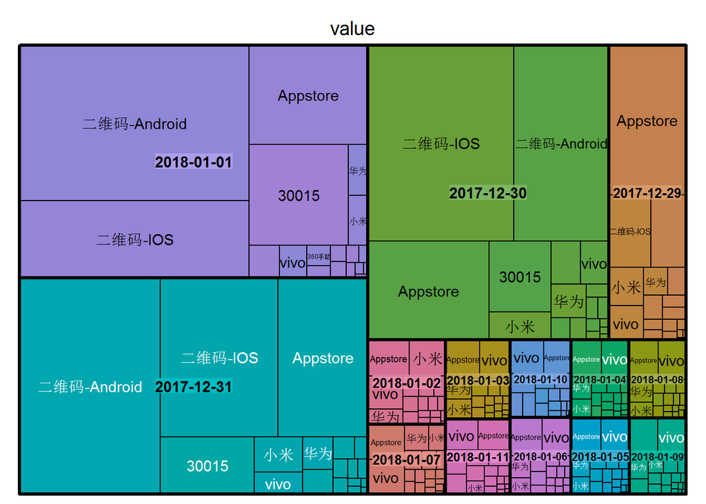

结构矩形树图，大矩形为日期，小矩形为具体渠道，按从大到小的顺序，从上到下，从左到右排列

# 转化问题

## 每日订单数

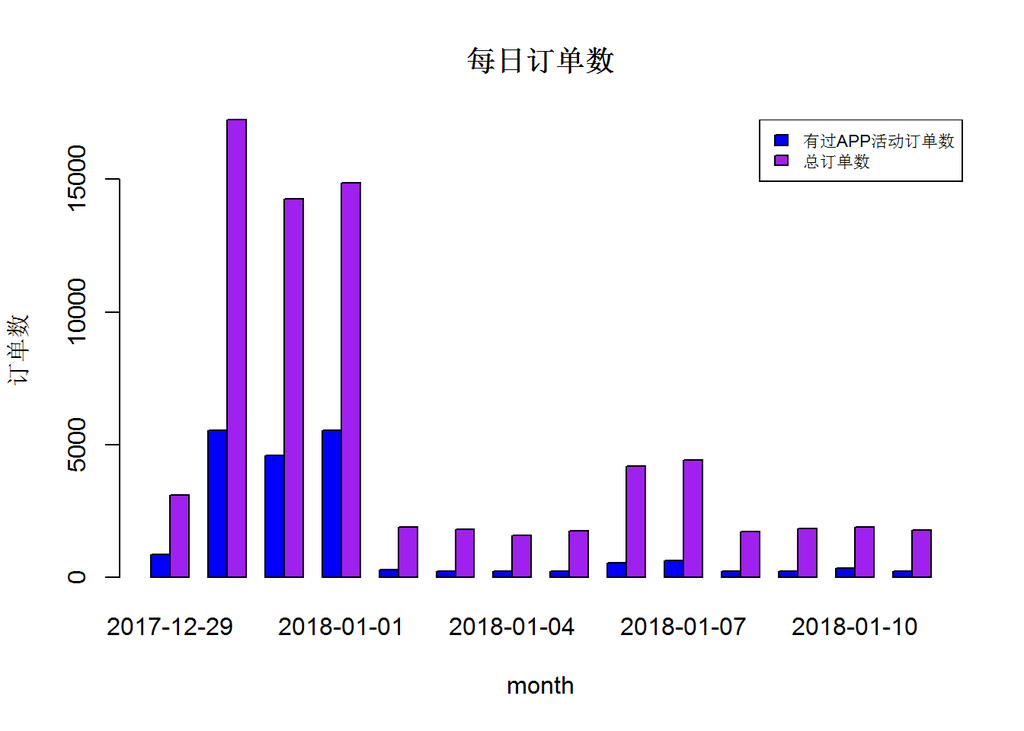

在APP上有过活动的人生成的订单占比较少，订单峰发生在12月30日，12月31日和2018年1月1日

## 家装预约

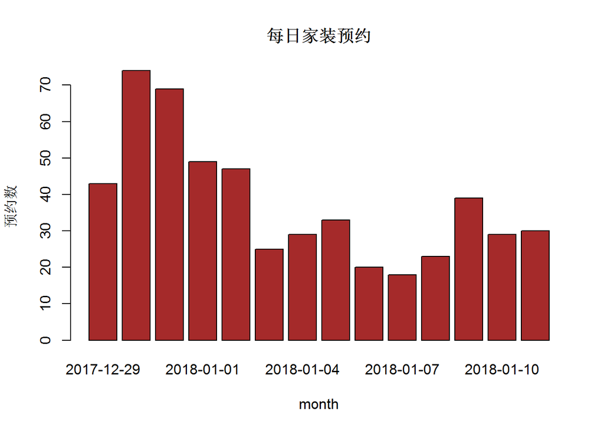

变化浮动没有往期那么大 12月30日31日附近比较高，年底效应？之后变化比较平稳

## 领券情况

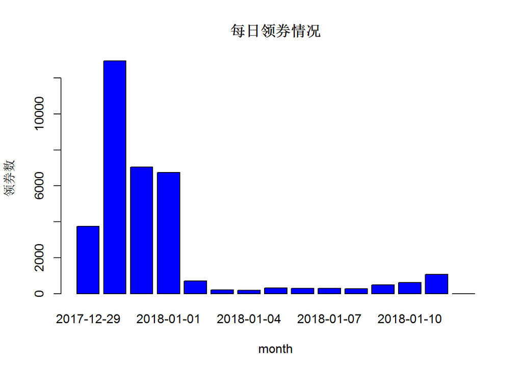

12月30日出现峰值，12月31日和1月1日数据有所回落，但仍然较高